# 2nd project of Mathematical-Computational Modeling (7600059)

## Professor: Luciano da Fontoura Costa

### Name: Victor Foscarini Almeida

### nUSP:10728101

```python
#libraries
import numpy as np
import scipy as sc
import matplotlib.pyplot as plt
from mpl_toolkits.mplot3d import axes3d
import matplotlib.patches as mpatches
from IPython.display import display

#colors
PURPLE = '\033[95m'
CYAN = '\033[96m'
DARKCYAN = '\033[36m'
BLUE = '\033[94m'
GREEN = '\033[92m'
YELLOW = '\033[93m'
RED = '\033[91m'
BOLD = '\033[1m'
UNDERLINE = '\033[4m'
END = '\033[0m'
```

### A. Consider the scalar field g (x, y) = x^2 + y^2. Obtain the minimum of this field using random search, as well as gradient descent with adaptive step, showing the minimum value obtained over the various interactions (mean +/- standard deviation). Compare the minimum curves between the random search and gradient descent considering several starting points.

- Note that the variation of the results for Random Search is notorious, for Gradient Descent it is not possible to see because the method is more accurate.
- When starting from an interval close to the minimum of the function, both the Gradient Descent method and the Random Search method are able to obtain the result, however starting from high values only the Gradient Descent method comes close.

```python
#random search
# n : number of random trials; loc_x : location of trials x; loc_y : location of trials y; statistics : show progress
def random_search(f,n,loc_x,loc_y,statistics=False):
    #generate random x,y
    x_random = np.random.uniform(*loc_x,n)
    y_random = np.random.uniform(*loc_y,n)

    if not statistics:

        z_random = f(x_random,y_random) #z function generated from random x and y
        return min(z_random)

    else:

        #create an array of smaller values
        smaller_z = f(x_random[0],y_random[0])
        minimums = [smaller_z]
        for i in np.arange(1,n):
            if f(x_random[i],y_random[i]) < smaller_z:
                smaller_z = f(x_random[i],y_random[i])
            minimums.append(smaller_z)
        return minimums


#gradient descent
# n : number of iterations; start : starting point; statistics : show progress
def gradient_descent(f,gf,n,start,learning_rate,statistics=False):
    #starting current value from given start
    curr = np.array(start)

    if not statistics:
        #apply gradient method
        for i in np.arange(n):
            prev = curr
            curr = curr - learning_rate * np.array(gf(*prev))

        return f(*curr)

    else:
        #apply gradient method storing values in array
        minimums = []
        for i in np.arange(n):
            prev = curr
            curr = curr - learning_rate * np.array(gf(*prev))
            minimums.append(f(*curr))

        return minimums

#gradient descent with annealing
def grad_annealing(f,gf,maxsteps=1000,temp_min=.01,loc_x=(-10,10),loc_y=(-10,10),cooling_factor=.95):

    #amplitude boundaries and initial temperature
    amp_x = amp_y = loc_x[1]-loc_x[0]
    T = 100*amp_x

    #initialize x and y randomly
    x_curr = np.random.uniform(*loc_x)
    y_curr = np.random.uniform(*loc_y)
    cost_curr = f(x_curr,y_curr)

    xs,ys,costs = [x_curr],[y_curr],[cost_curr]

    #for step in range(int((maxsteps-1)/2)):
    step = 0
    while step < int((maxsteps-1)/2) :

        progress = 1 - step/maxsteps
        step+=1
        T *= cooling_factor # temperature decresses through process

        grad = gf(x_curr,y_curr,f)

        #move x e y a little and make sure they are still on interval
        x_new = min(loc_x[1],max(x_curr - grad[0] + progress*np.random.uniform(-amp_x/2,amp_x/2),loc_x[0]))
        y_new = min(loc_y[1],max(y_curr - grad[1] + progress*np.random.uniform(-amp_x/2,amp_x/2),loc_y[0]))
        cost_new = f(x_new,y_new)

        if (cost_new < cost_curr) or (np.exp((cost_curr-cost_new)/T) > np.random.random()):

            x_curr,y_curr,cost_curr = x_new,y_new,cost_new

        xs.append(x_curr)
        ys.append(y_curr)
        costs.append(cost_curr)

    while step < (maxsteps-1) :

        grad = gf(x_curr,y_curr,f)

        x_curr = x_curr - grad[0]*.01
        y_curr = y_curr - grad[1]*.01
        cost_curr = f(x_curr,y_curr)

        xs.append(x_curr)
        ys.append(y_curr)
        costs.append(cost_curr)

        step+=1

    return np.array([xs,ys,costs])
```

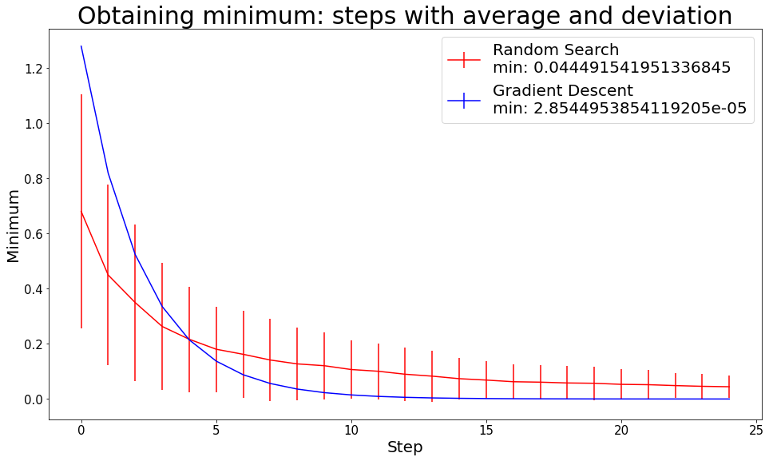

```python
#function f
f = lambda x,y : x**2 + y**2

#gradient of function f
gf = lambda x,y : [2*x,2*y]


#initially, check the progress of the methods in case of
#n = 25 and initial values around 1 with a learning rate of 0.1
# the accounts are repeated 100 times and average and deviation are used

learning_rate,ini,n,rep = 0.1,1,25,100

rep = 100
random_search_results = np.empty([rep,n])
gradient_descent_results = np.empty([rep,n])

for i in range(rep):
    random_search_results[i,:] = random_search(f,n,[-ini,ini],[-ini,ini],True)
    gradient_descent_results[i,:] = gradient_descent(f,gf,n,[ini,ini],learning_rate,True)

random_search_mean = random_search_results.mean(0)
random_search_std = random_search_results.std(0)

gradient_descent_mean = gradient_descent_results.mean(0)
gradient_descent_std = gradient_descent_results.std(0)

#plot graphics
plt.figure(figsize=(16,9))
plt.errorbar(np.arange(n),random_search_mean,yerr=random_search_std,color='red',
         label='Random Search\n'+'min: '+str(random_search_mean[-1]))
plt.errorbar(np.arange(n),gradient_descent_mean,yerr=gradient_descent_std,color='blue',
         label = 'Gradient Descent\n'+'min: '+str(gradient_descent_mean[-1]))
plt.xlabel('Step', fontsize = 20)
plt.ylabel('Minimum', fontsize = 20)
plt.xticks(fontsize = 15)
plt.yticks(fontsize = 15)
plt.legend(loc='upper right',fontsize=20)
plt.title("Obtaining minimum: steps with average and deviation",fontsize=30)
plt.show()
```

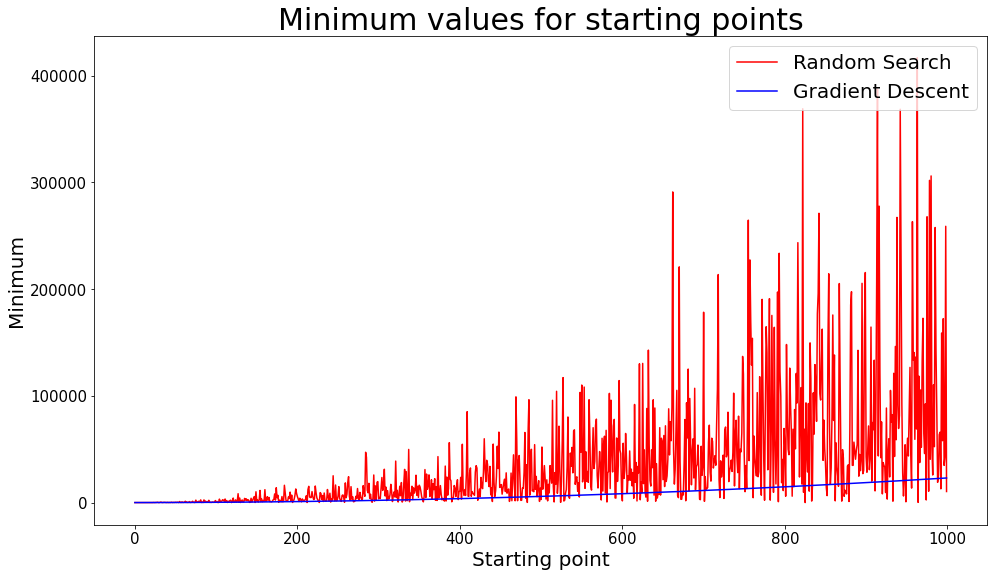

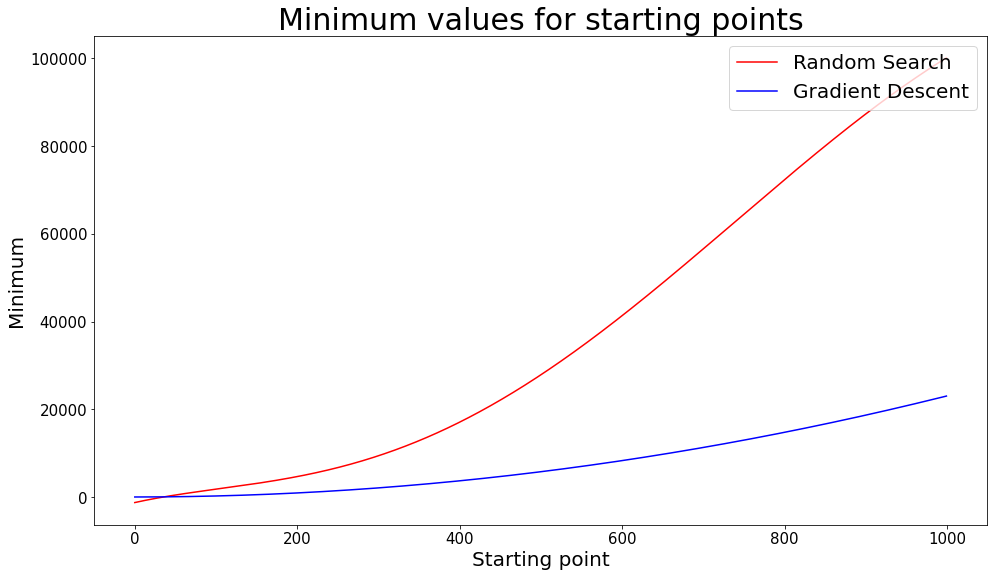

```python
#let's use number of fixed steps
# we vary initial values (from initial poin in gradient descent and initial area in random_searc)

learning_rate,num_passos,initial_max = 0.1,10,1000

random_search_results = np.zeros(initial_max)
gradient_descent_results = np.zeros(initial_max)

for i in np.arange(1,initial_max):
    random_search_results[i] = random_search(f,num_passos,[-i,i],[-i,i])
    gradient_descent_results[i] = gradient_descent(f,gf,num_passos,[-i,i],learning_rate)

#plot graphics
plt.figure(figsize=(16,9))
plt.plot(np.arange(initial_max),random_search_results,color='red',label='Random Search')
plt.plot(np.arange(initial_max),gradient_descent_results,color='blue',label = 'Gradient Descent')
plt.xlabel('Starting point', fontsize = 20)
plt.ylabel('Minimum', fontsize = 20)
plt.xticks(fontsize = 15)
plt.yticks(fontsize = 15)
plt.legend(loc='upper right',fontsize=20)
plt.title("Minimum values for starting points",fontsize=30)
plt.show()

#plot graphics treating random as polinomial function

random_search_model = np.poly1d(np.polyfit(np.arange(initial_max),random_search_results,5))

plt.figure(figsize=(16,9))
plt.plot(np.arange(initial_max),random_search_model(np.arange(initial_max)),color='red',label='Random Search')
plt.plot(np.arange(initial_max),gradient_descent_results,color='blue',label = 'Gradient Descent')
plt.xlabel('Starting point', fontsize = 20)
plt.ylabel('Minimum', fontsize = 20)
plt.xticks(fontsize = 15)
plt.yticks(fontsize = 15)
plt.legend(loc='upper right',fontsize=20)
plt.title("Minimum values for starting points",fontsize=30)
plt.show()
```